# Gráficos para o relatório

# Índices

## Dataset

```r
# `indice_long`: pontuações por critérios e dimensões por órgão, ano, mes e status no formato long.
indice_long <- readRDS(here("data/load/indice-long.rds"))
```

`indice_long` é preparado neste script

```r
indice_long
```

```
#> # A tibble: 6.864 x 7
#>    orgao   ano   mes criterio            pontuacao dimensao   status
#>    <chr> <int> <int> <chr>                   <dbl> <chr>      <chr>
#>  1 MP-RO  2018     1 Tem lotação                 1 Completude Ok
#>  2 MP-RO  2018     1 Tem cargo                   1 Completude Ok
#>  3 MP-RO  2018     1 Tem matrícula               1 Completude Ok
#>  4 MP-RO  2018     1 Receita base                1 Completude Ok
#>  5 MP-RO  2018     1 Despesas                    1 Completude Ok
#>  6 MP-RO  2018     1 Outras receitas             1 Completude Ok
#>  7 MP-RO  2018     1 Nao requer login            1 Facilidade Ok
#>  8 MP-RO  2018     1 Nao requer captcha          1 Facilidade Ok
#>  9 MP-RO  2018     1 Acesso                      0 Facilidade Ok
#> 10 MP-RO  2018     1 Formato consistente         1 Facilidade Ok
#> # ... with 6.854 more rows
```

## Calculando índice

Completude e Facilidade é a média aritmética simples de seus respectivos critérios:

```r
# `indice` contém os índices de Completude, Facilidade
indice <- indice_long %>%
  group_by(mes, ano, orgao, dimensao) %>%
  summarise(indice = mean(pontuacao), .groups = "drop") %>%
  pivot_wider(names_from = dimensao, values_from = indice)
```

O Índice de Transparência é a média harmônica dos índices de Completude e Facilidade:

```r
# Função que faz o cálculo da média harmônica em `indice`
media_harmonica <- function(x,y) if_else(x + y == 0, 0, ((x * y) / (x + y)) * 2)
```

```r
# `indice` contém os índices de Completude, Facilidade e Transparência
indice <- indice %>%
  mutate(Transparência = media_harmonica(Completude, Facilidade))
```

|  | mes | ano | orgao | Completude | Facilidade | Transparência |
| --- | --- | --- | --- | --- | --- | --- |
| 1 | 1 | 2018 | MP-AL | 1 | 0.7 | 0.823529411764706 |
| 2 | 1 | 2018 | MP-AM | 0 | 0 | 0 |
| 3 | 1 | 2018 | MP-AP | 0.75 | 0.6 | 0.666666666666667 |
| 4 | 1 | 2018 | MP-CE | 1 | 0.85 | 0.918918918918919 |
| 5 | 1 | 2018 | MP-DFT | 1 | 0.7 | 0.823529411764706 |
| 6 | 1 | 2018 | MP-GO | 0.916666666666667 | 0.9 | 0.908256880733945 |
| 7 | 1 | 2018 | MP-MG | 1 | 0.7 | 0.823529411764706 |
| 8 | 1 | 2018 | MP-MS | 1 | 0.8 | 0.888888888888889 |
| 9 | 1 | 2018 | MP-MT | 0.916666666666667 | 0.7 | 0.793814432989691 |
| 10 | 1 | 2018 | MP-PB | 1 | 0.7 | 0.823529411764706 |

[output cut: 614 more lines]

## Índices média geral

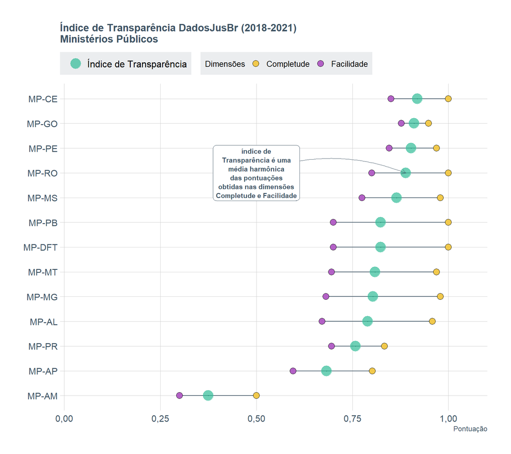

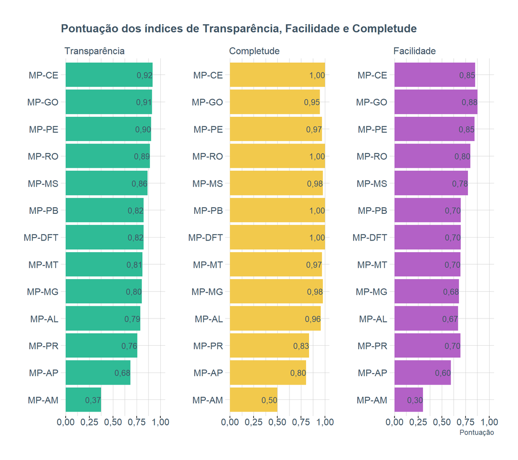

## Demonstração do cálculo da média geral: estado do Amazonas

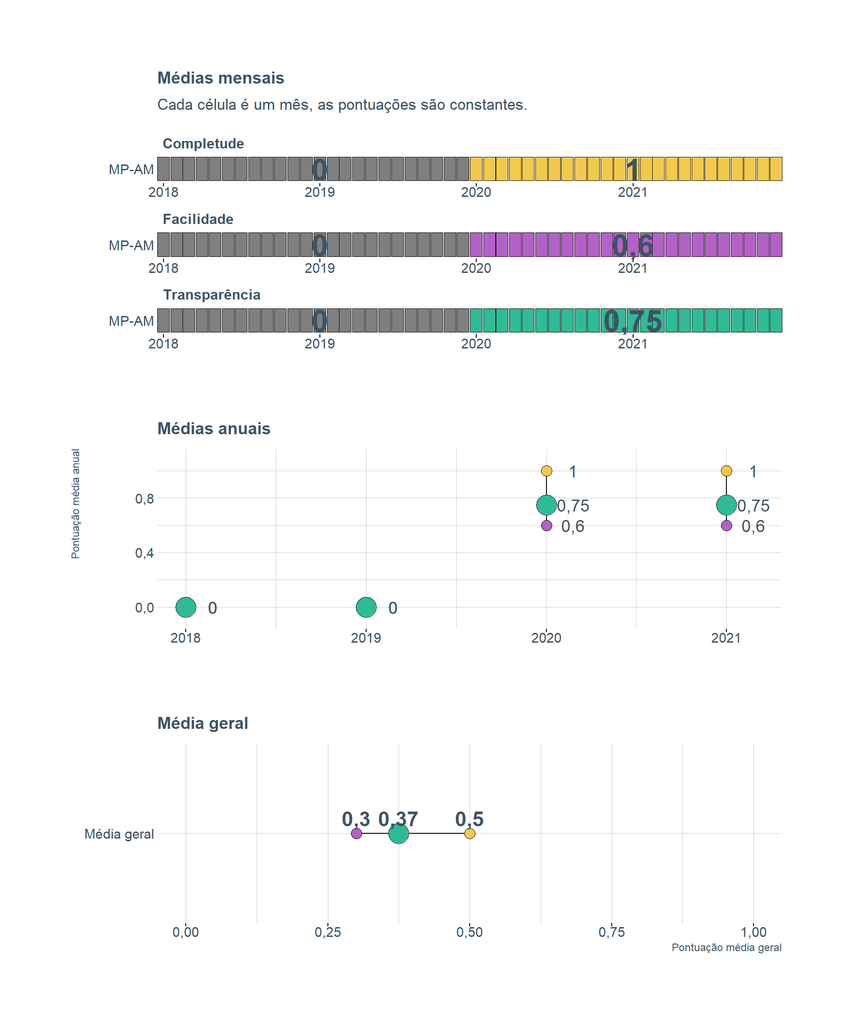

## Pontuação média por mês e órgão

### Transparência

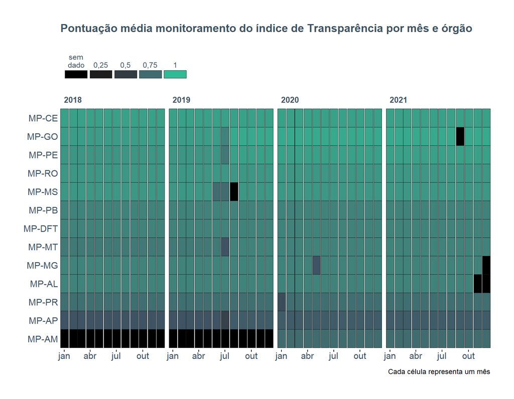

### Facilidade

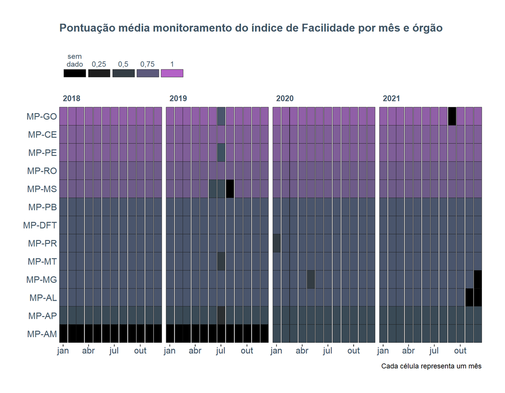

### Completude

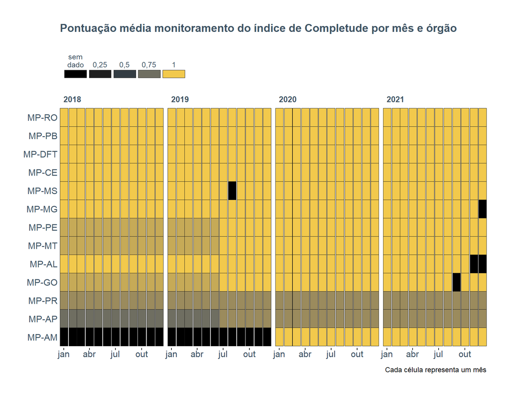

## Média mensal entre todos os órgãos

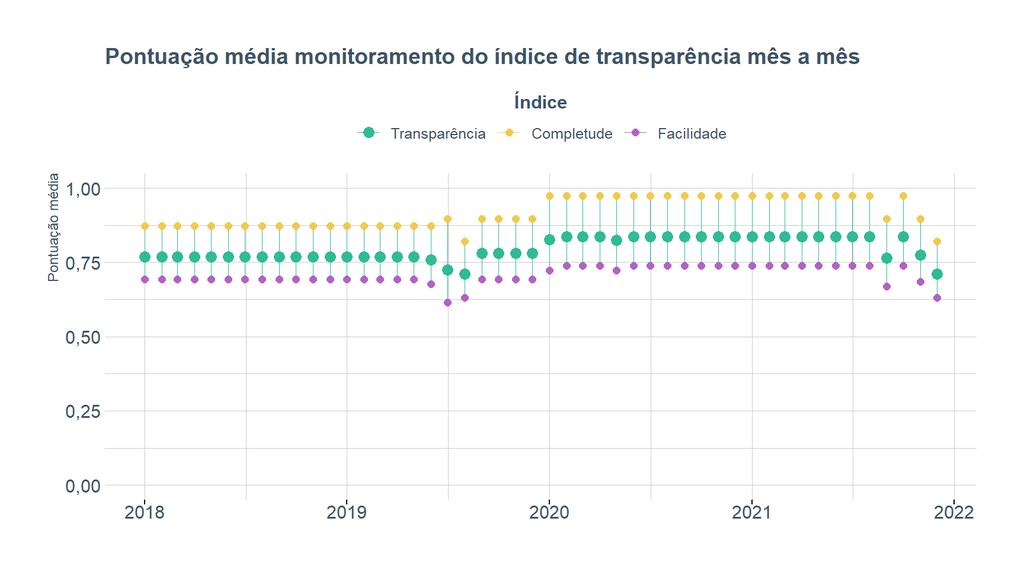

# Índice de Facilidade

- Necessidade de login
- Necessário captcha
- Formato de acesso
- Manteve consistência no formato
- Formato estritamente tabular

## Formato de acesso

**Definição**: Se é possível acessar os dados programaticamente através de URLs que seguem boas práticas, se é necessário raspar os dados de maneira fácil (pois páginas e URLs têm boas práticas de estrutura), se é necessário raspagem complexa ou se é necessário simular um usuário usando um navegador (pior caso).

**Valores**:

- $1,00$: o acesso é feito de forma **DIRETA**, através de URLs que seguem boas práticas
- $0,50$: o acesso é **AMIGAVEL PARA RASPAGEM**
- $0,25$: o acesso **NÃO É AMIGAVEL PARA RASPAGEM**
- $0,00$: é **NECESSÁRIO SIMULAÇÃO DE USUÁRIO** para acesso

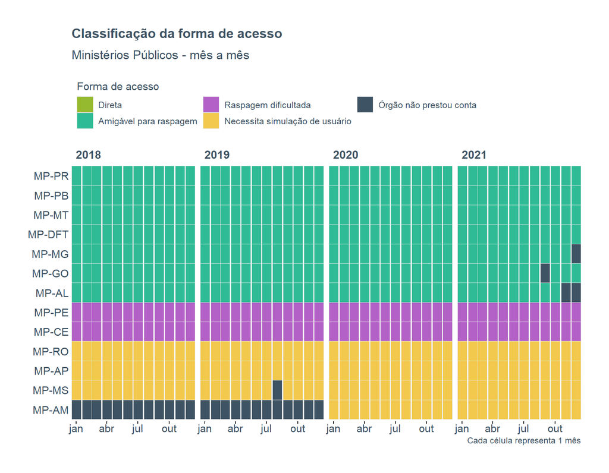

## Manteve consistência do formato

**Definição**: Esse campo captura se houve mudanças no formato como os dados que foram disponibilizados.

**Valores**:

- $1,00$: quando o formato é consistente
- $0,00$: quando o formato não é consistente

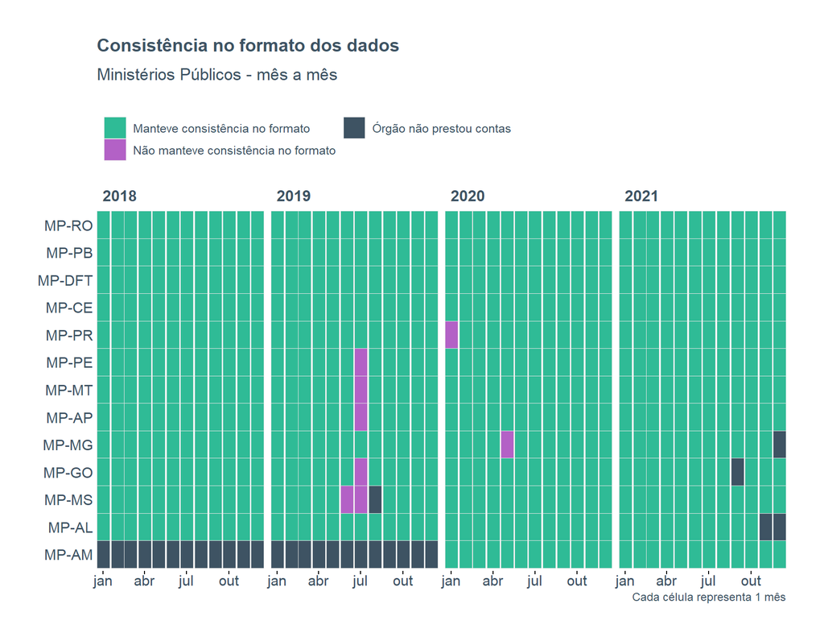

## Formato estritamente tabular

**Definição**: Os dados estão em formato que permite importação direta em software de análise ou precisam ser processados primeiro (por ex. por estarem em um doc ou pdf).

**Valores**:

- $1,00$: quando o formato é estritamente tabular
- $0,00$: quando o formato não é estritamente tabular

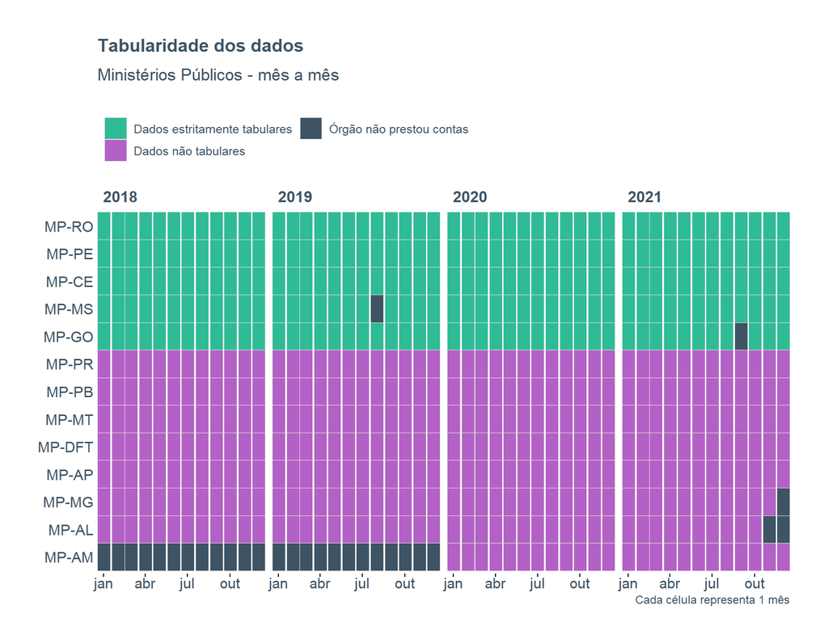

# Índice de Completude

- Nome e matrícula
- Lotação
- Cargo
- Remuneração básica
- Outras receitas
- Detalhamento de despesas

### Nome e matrícula

**Definição**: Nome e número de identificação do funcionário

**Valores**:

- $1,00$: possui ambos os atributos
- $0,00$: não possui um dos atributos

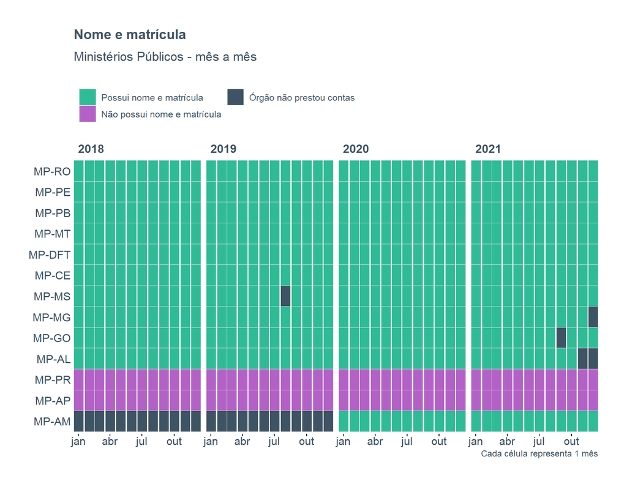

### Lotação

**Definição**: local onde o sercidor exerce as atribuições e responsabilidades do cargo público.

**Valores**:

- $1,00$: possui o atributo lotação
- $0,00$: não possui o atributo lotação

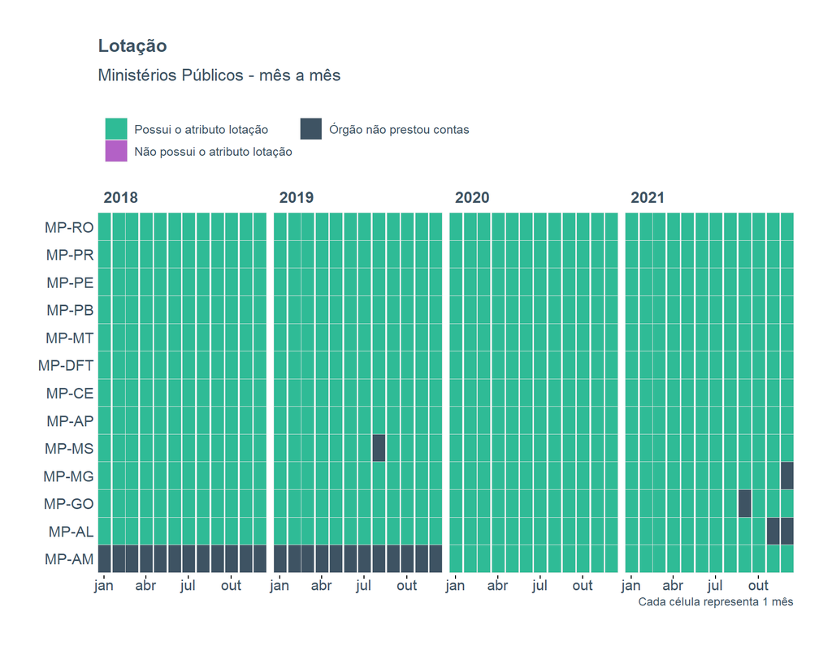

### Cargo

**Definição**: função que o servidor exerce no órgão.

**Valores**:

- $1,00$: possui o atributo cargo
- $0,00$: não possui o atributo cargo

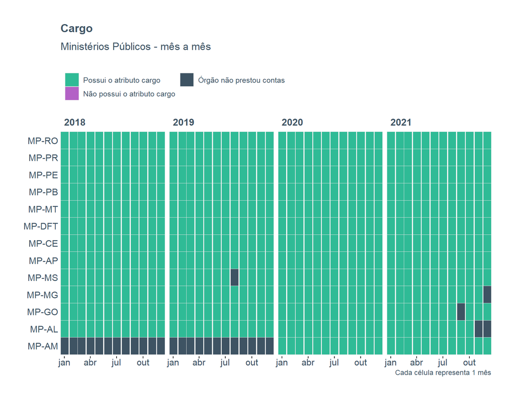

### Remuneração básica

**Definição**: para os Ministérios Públicos o valor da remuneração básica é composto pela soma do valor da remuneração do Cargo Efetivo e o valor correspondente a outras verbas remuneratórias, legais ou judiciais.

**Valores**:

- $1,00$: apresenta remuneração básica **detalhada**
- $0,50$: apresenta remuneração básica **sumarizada**
- $0,00$: não apresenta remuneração básica

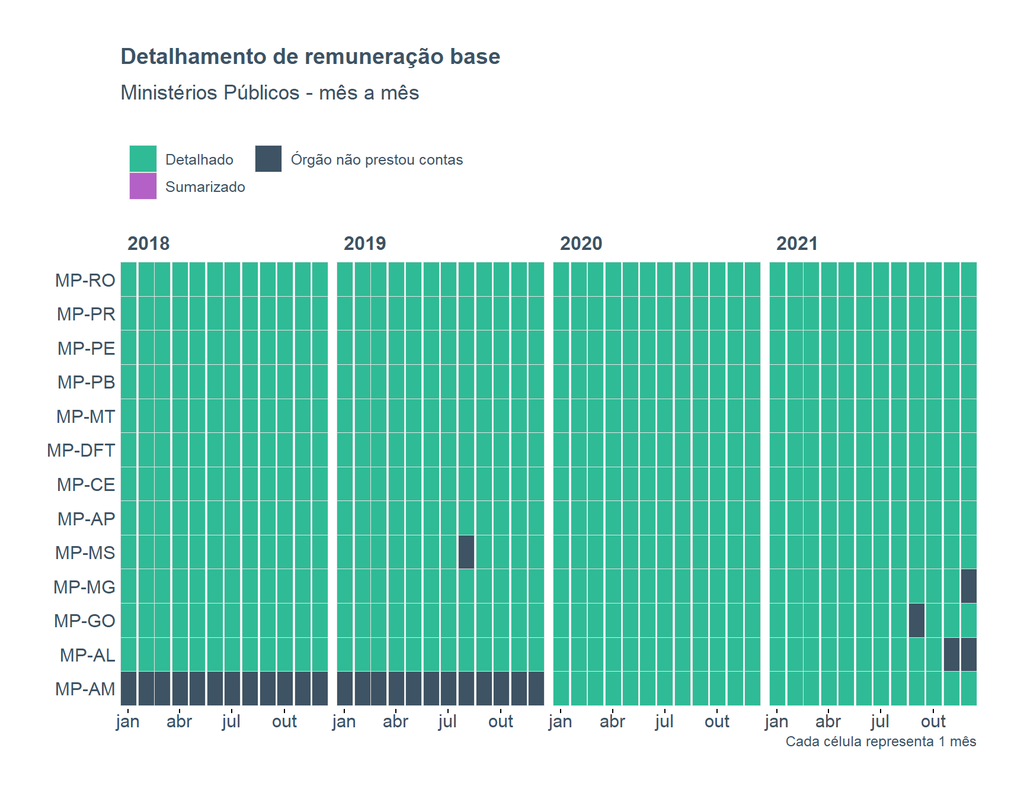

### Despesas

**Definição**: valor correspondentes a descontos obrigatórios como: Contribuição Previdenciária, Imposto de Renda e Retenção por Teto Constitucional

**Valores**:

- $1,00$: apresenta despesas **detalhadas**
- $0,50$: apresenta despesas **sumarizadas**
- $0,00$: não apresenta despesas

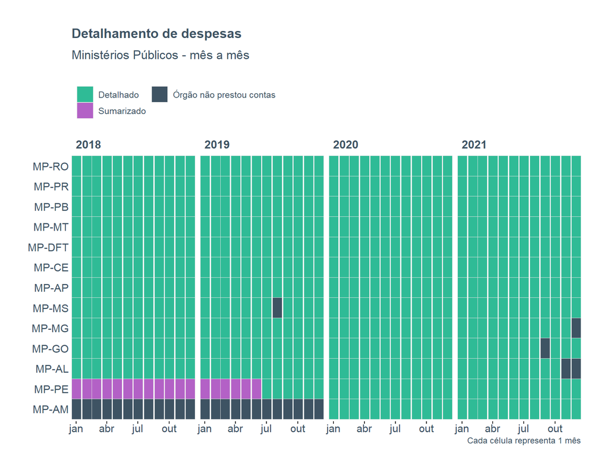

### Outras remunerações

**Definição**: ínclui remuneração eventual ou temporária, tais como: função de confiança ou cargo em comissão, gratificação natalina, férias constitucionais, abono permanência, insalubridade, bem como as indenizações, por exemplo: pecúnias ou auxílios como: alimentação, saúde, creche, moradia, natalidade.

**Valores**:

- $1,00$: apresenta outras receitas **detalhadas**
- $0,50$: apresenta outras receitas **sumarizadas**
- $0,00$: não apresenta outras receitas

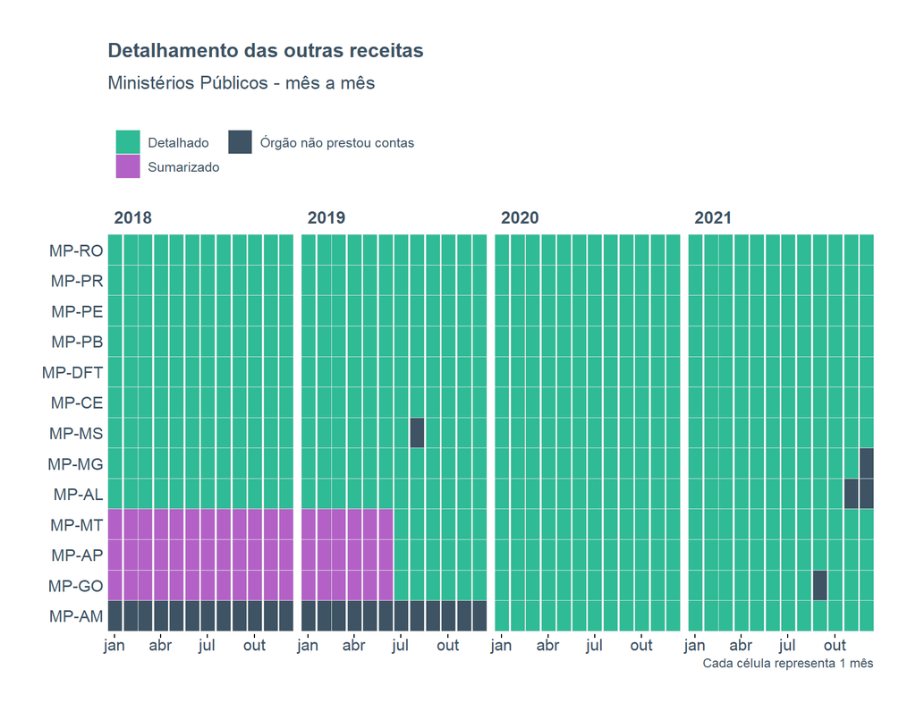

# Planilhas de contra cheques mensais consolidadas

Número de planilhas processadas:

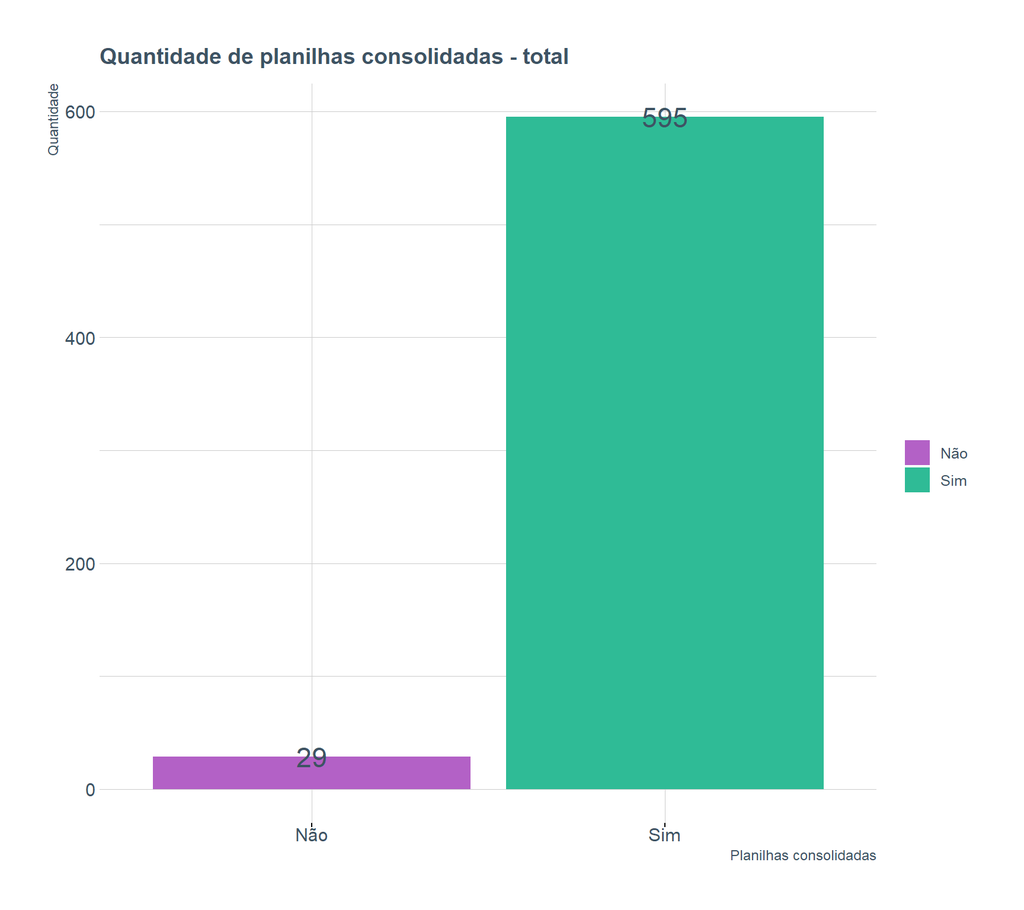

Número de planilhas processadaas por órgão:

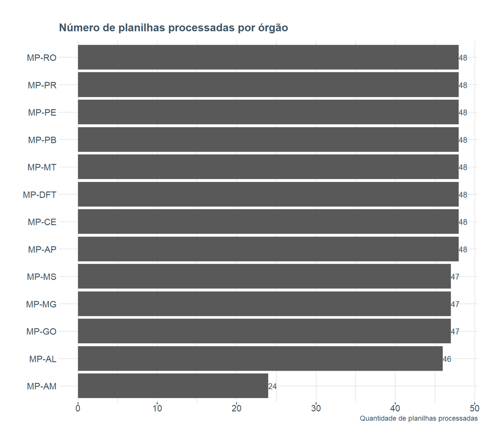